# Data Science for Socioeconomists

Excercise 5 - Data visualization pt. 1

Lisa Wegner

# Agenda for today

1. Motivation
2. Finding the right plot for your purpose
3. Advanced Plotting with ggplot
4. Tasks
5. Outlook for next week

# 1. Motivation

Why should we do visualizations?

Why should we keep certain principles in mind?

How can we make our graphics accessible?

[figure not shown]

Benefits of data science visualization via turing.com

# 2. The right plot for your purpose

## Types of Plots

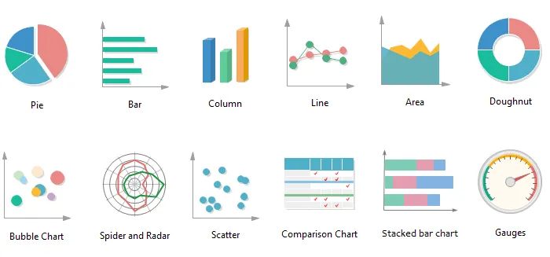

via https://medium.com/@Lynia_Li/as-you-know-there-are-many-types-of-charts-to-be-used-in-data-visualization-54da9b97092e

## Boxplot

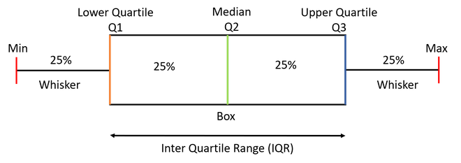

via: [geeksforgeeks](https://www.geeksforgeeks.org/box-plot/)

## Help for your decision

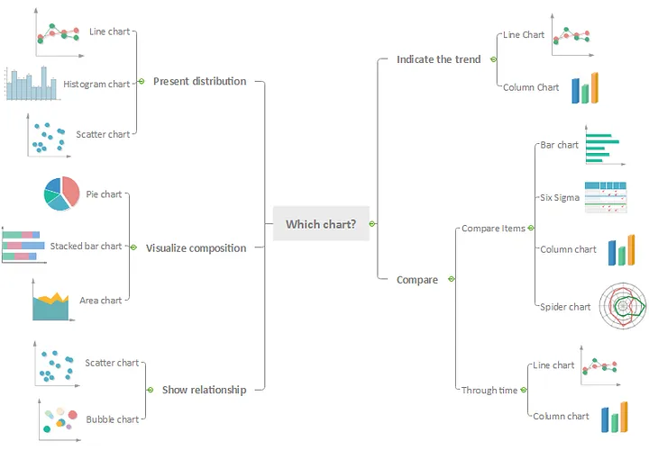

via https://medium.com/@Lynia_Li/as-you-know-there-are-many-types-of-charts-to-be-used-in-data-visualization-54da9b97092e

## **Little quiz**

Which plot-type is recommended for which purpose?

https://particify.uni-hamburg.de/p/61346493

[figure not shown]

# 3. Plotting with ggplot2

Since you have already done this in the lecture we’ll go through the following slides a bit quicker!

We will use randomly generated data (test_dataset) to get an overview over the functions of ggplot2

I’ve loaded the data set from the package `sozoekds` already

## Idea

```
ggplot(data = <DATA>, mapping = aes(<MAPPINGS>))
+ <GEOM_FUNCTION>()
```

1. choose dataset: `data = dataset`
2. add `mapping = aes(x=var1, y=var2)`
3. with this you get the basic coordinate system
4. add layers with further information to the plot
   1. What kind of diagram do I want?
   2. Which functions do I need for that?
   3. What parameters are needed?

## 1st step : adding data, colors and different variables

```r
library(sozoekds)
test_dataset <- testdata
library(ggplot2)
ggplot(data = test_dataset,mapping = aes(x=age)) +
  geom_point(mapping=aes(y= income),
                    color="darkgreen")  +
  # we have added a color for the viz of age & income
          geom_point(mapping=aes(y=spending_habits),
                     color ="red")
```

```r
# adding a new variable - the connection should be visualized in red
```

[figure not shown]

## 2nd: adding labels

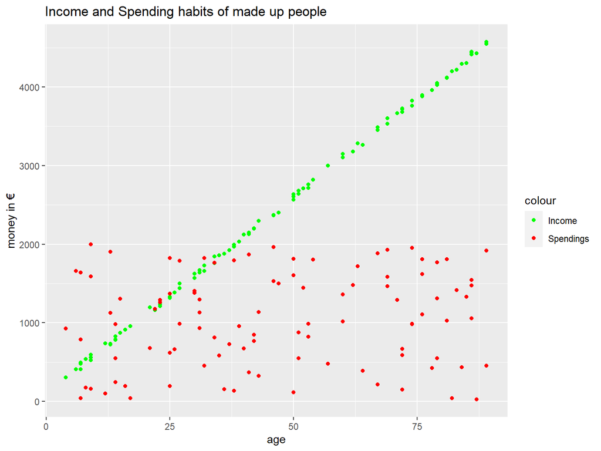

```r
p <- ggplot(data = test_dataset, mapping = aes(x=age)) +
  # dataset and x-variable to plot are defined
  geom_point(aes(y = income, color = "Income")) +
  #y gets the color "Income" assigned - we later tell what this color represents
  geom_point(aes(y = spending_habits, color = "Spendings")) +
  #y gets the color "Spendings" assigned
  # we later tell what this color represents
  labs(x = "age", y = "money in €",
       title = "Income and Spending habits of made up people") +
  #adding a title and axis-labels
  scale_colour_manual(breaks = c("Income", "Spendings"),
                      values = c("green", "red"))
# assigning colors to the color-representors

p
```

## Global vs. local aesthetic

*global aesthetic:*

aesthetic is defined on the first layer and is used for all following layers - unless a local aesthetic over-writes it

*local aesthetic:*

aesthetic is defined for each layer independently

- within the first layer we set global values within our plot: `ggplot(data = data, mapping=aes())`
- within the `geom_point(aes()`) layer we can overwrite the global aesthetic and set a local one

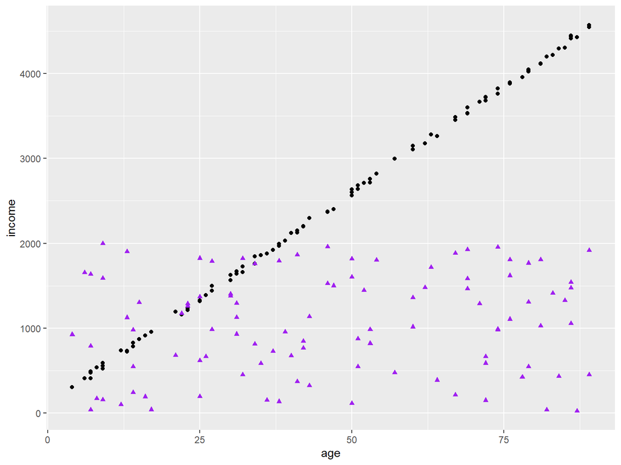

```r
p <- ggplot(data = test_dataset,mapping = aes(x= age)) +
  geom_point(mapping=aes (y=income)) +
  geom_point(mapping=aes(y=spending_habits),
             color ="purple", shape="triangle")
p
```

## Variations

For changes in the theme like color, size of points, type of points etc. look for `ggplot2-specs` in the help-console

There are plenty more types of visualization available https://ggplot2.tidyverse.org/reference/

**[`geom_bar()`](https://ggplot2.tidyverse.org/reference/geom_bar.html) [`geom_col()`](https://ggplot2.tidyverse.org/reference/geom_bar.html) [`stat_count()`](https://ggplot2.tidyverse.org/reference/geom_bar.html)**

Bar charts

**[`geom_dotplot()`](https://ggplot2.tidyverse.org/reference/geom_dotplot.html)**

Dot plot

**[`geom_freqpoly()`](https://ggplot2.tidyverse.org/reference/geom_histogram.html) [`geom_histogram()`](https://ggplot2.tidyverse.org/reference/geom_histogram.html) [`stat_bin()`](https://ggplot2.tidyverse.org/reference/geom_histogram.html)**

Histograms and frequency polygons

## Cheatsheet

Since there are a lot of different options to choose from, some websites might be helpful:

Data Camp on ggplot2

[Cheat Sheet from GitHub](https://rstudio.github.io/cheatsheets/html/data-visualization.html)

And as always: using the Help-Function in R-Studio and using Google with a term like `geom_boxplot` is really helpful. There are many options to choose from. Sometimes we have to try a few times to find a plot that suits our purpose and needs.

Example: Description on the [Boxplot](https://ggplot2.tidyverse.org/reference/geom_boxplot.html) in ggplot2

# 4. Exercises for today

## Preface

We’ll be working with California Housing Data and Exam Data today and in next weeks session. The two data sets can be found in the package `sozoekds` (see last weeks exercise on how to download it or look into the [Read Me](https://gitlab.rrz.uni-hamburg.de/BAQ6370/sozoekds) ).

The data sets have added information about their content - like how the variables are measured, what the measure etc. Looking at the description is helpful since a variable in a data set could have a name like `Median_Age` (in calhouse) which I might think is the…

- Median age of the inhabitants of the house?
- The age of the person who did the observation?
- The median age of a house within a block?

`Median_Age` measures the last thing - it it measures it on a block-scale. This way it’s already an aggregated value for multiple buildings. We can still calculate the mean or median over all observations.

## Todays and next weeks exercises

Now: Work in a Quarto Document with your group on the Jupyter Hub!

- Choose just **one** of the two data sets (calhouse or examdata) and do the responding exercises.
- While doing the tasks:
  - Please choose an accurate type of plot for the purpose of the question.
  - Give an explanation on why this type of visualization is accurate.
  - Also look at the scales, colors, headlines, type and size of lines/dots, legends… - and choose a style that fits.

## California Housing

*today*

1. Create a diagram that visualizes the distribution of the Median House Value
2. Afterwards create a diagram that puts Median House Value and the distance to the coast together
3. Add labels, color and scales in a way that suit the purpose of your graphic
4. Explain your decision of the type of visualization
5. Interpret the result

*next week*

1. Revisit last weeks plots - how can you re-style them with the principles we learned today?
2. New plot(s)
   1. Create a new variable called `Avg_Rooms` that displays the average amount of rooms in each household in a certain neighborhood (block)

      *Hint: for one observation there might be 20 households, and 50 rooms in total - this leads to an average of 2.5 rooms per household*
   2. Plot Avg_Rooms against Median_Income - interpret the result
   3. Eliminate values in Avg_Rooms that are greater then 10 rooms from your data set - then plot task 2 again
   4. as before: Explain your decision of the type of visualization + Interpret the results

## Exam Scores

*today*

1. Create a diagram that visualizes the distribution of the MathScore
2. Plot the distribution of the different test scores in regards to Gender
3. Add labels, color and scales in a way that suit the purpose of your graphic
4. Explain your decision of the type of visualization
5. Interpret the result

*next week*

1. Revisit last weeks plots - how can you re-style them with the principles we learned today?
2. New plot(s)
1. Create a new variable called `full_score` that is the mean score of all three testscores (Math, Reading, Writing)
2. Calculate grades from the `full_score` using the american system ([hint here](https://en.wikipedia.org/wiki/Academic_grading_in_the_United_States))
3. Plot the distribution of grades by number of study hours per week  
   Hint: create a factor variable from WklyStudyHours

   Hint: You could do this in one plot with multiple lines or in more than one graphic where all the plots are printed in one frame (https://intro2r.com/mult_graphs.html)
4. as before: Explain your decision of the type of visualization + Interpret the results

# Next week

Adding labels, axis-titles, changing colors, thinking about accessibility

Data Science for Socioeconomists